[figure not shown]

# Heart Disease Prediction: End-to-End ML Pipeline

## Dataset Source and Business Context

This project works with the Heart Disease dataset, which has clinical details from patients who went through cardiovascular assessments. It’s got everything—age, chest pain descriptions, cholesterol, resting blood pressure, maximum heart rate, and info about angina that shows up during exercise.

Heart disease is a big deal globally, still one of the main reasons people die. Spotting risky cases early really helps: it lets doctors step in sooner, improve recovery chances, and avoid the heavy costs of late-stage treatment. ML is a good tool for this case. It can help us to find connections between all these clinical factors and help doctors figure out which factors needs a closer look.

The goal of this project is to use the dataset info to build and test models that can helps us in prediction of heart disease risk, based on patient details and medical stats.

All files associated to this project can be found in the link below.

Source: https://github.com/Negi-Ashish/M505A-Intro-to-AI-and-Machine-Learning

## 1. Business Problem Statement

Cardiovascular disease kills about 17.9 million people every year that’s nearly a third of all deaths worldwide (WHO, 2021). Catching these factors early can really make a difference, helping doctors step in sooner and making the most of healthcare resources. In this project, I’m building a binary classifier to predict heart disease (1 for disease, 0 for no disease) using 13 routine clinical features, all from the UCI Heart Disease dataset (Janosi et al., 1988). The goal? Help clinicians spot high-risk patients before symptoms get worse. I’m using F1-score and AUC-ROC to see how well the model does, since missing a sick patient can cost far more than a false alarm. All the data comes from Cleveland Clinic and is open to everyone through the UCI Machine Learning Repository.

```python
import numpy as np
import pandas as pd
import matplotlib.pyplot as plt
import seaborn as sns
from sklearn.linear_model import LogisticRegression
from sklearn.neighbors import KNeighborsClassifier
from sklearn.svm import SVC
from sklearn.tree import DecisionTreeClassifier
from sklearn.naive_bayes import GaussianNB
from sklearn.ensemble import RandomForestClassifier
from sklearn.pipeline import Pipeline
from sklearn.model_selection import train_test_split, cross_val_score, RandomizedSearchCV
from sklearn.preprocessing import StandardScaler
from sklearn.metrics import classification_report, confusion_matrix, RocCurveDisplay

np.random.seed(42)
```

## 2. Dataset Overview and Data Quality Assessment

```python
heart_df = pd.read_csv("./heart-disease.csv")
print(f"Shape: {heart_df.shape} | Duplicates: {heart_df.duplicated().sum()} | Missing values: {heart_df.isnull().sum().sum()}")
print(f"\nClass distribution:\n{heart_df.target.value_counts().to_string()}")
heart_df.describe()
```

```
Shape: (303, 14) | Duplicates: 1 | Missing values: 0

Class distribution:
target
1    165
0    138
```

|  | age | sex | cp | trestbps | chol | fbs | restecg | thalach | exang | oldpeak | slope | ca | thal | target |
| --- | --- | --- | --- | --- | --- | --- | --- | --- | --- | --- | --- | --- | --- | --- |
| count | 303.000000 | 303.000000 | 303.000000 | 303.000000 | 303.000000 | 303.000000 | 303.000000 | 303.000000 | 303.000000 | 303.000000 | 303.000000 | 303.000000 | 303.000000 | 303.000000 |
| mean | 54.366337 | 0.683168 | 0.966997 | 131.623762 | 246.264026 | 0.148515 | 0.528053 | 149.646865 | 0.326733 | 1.039604 | 1.399340 | 0.729373 | 2.313531 | 0.544554 |
| std | 9.082101 | 0.466011 | 1.032052 | 17.538143 | 51.830751 | 0.356198 | 0.525860 | 22.905161 | 0.469794 | 1.161075 | 0.616226 | 1.022606 | 0.612277 | 0.498835 |
| min | 29.000000 | 0.000000 | 0.000000 | 94.000000 | 126.000000 | 0.000000 | 0.000000 | 71.000000 | 0.000000 | 0.000000 | 0.000000 | 0.000000 | 0.000000 | 0.000000 |
| 25% | 47.500000 | 0.000000 | 0.000000 | 120.000000 | 211.000000 | 0.000000 | 0.000000 | 133.500000 | 0.000000 | 0.000000 | 1.000000 | 0.000000 | 2.000000 | 0.000000 |
| 50% | 55.000000 | 1.000000 | 1.000000 | 130.000000 | 240.000000 | 0.000000 | 1.000000 | 153.000000 | 0.000000 | 0.800000 | 1.000000 | 0.000000 | 2.000000 | 1.000000 |
| 75% | 61.000000 | 1.000000 | 2.000000 | 140.000000 | 274.500000 | 0.000000 | 1.000000 | 166.000000 | 1.000000 | 1.600000 | 2.000000 | 1.000000 | 3.000000 | 1.000000 |
| max | 77.000000 | 1.000000 | 3.000000 | 200.000000 | 564.000000 | 1.000000 | 2.000000 | 202.000000 | 1.000000 | 6.200000 | 2.000000 | 4.000000 | 3.000000 | 1.000000 |

## 3. Exploratory Data Analysis

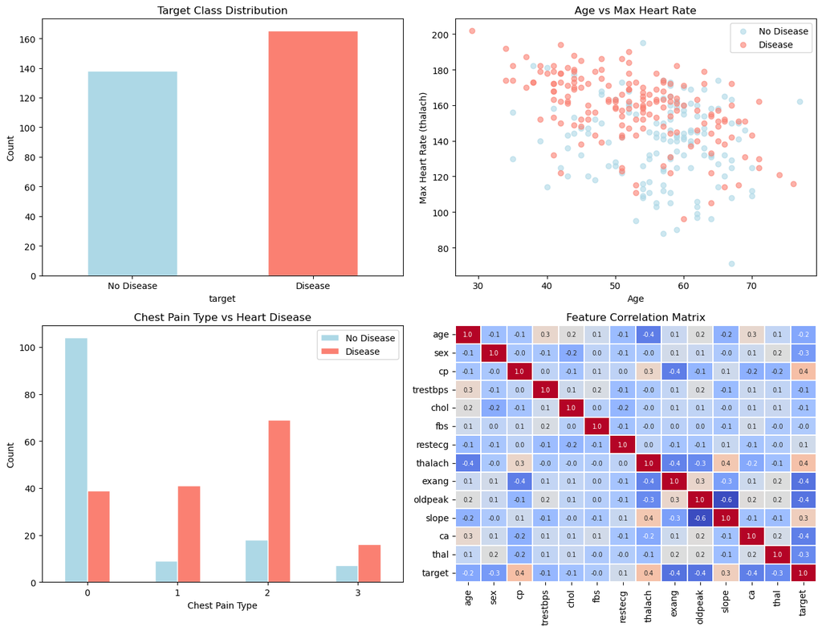

```python
fig, ax_grid = plt.subplots(2, 2, figsize=(13, 10))

heart_df.target.value_counts().reindex([0, 1]).plot(kind='bar', ax=ax_grid[0, 0],
    color=['lightblue', 'salmon'], edgecolor='white')
ax_grid[0, 0].set_title('Target Class Distribution')
ax_grid[0, 0].set_xticklabels(['No Disease', 'Disease'], rotation=0)
ax_grid[0, 0].set_ylabel('Count')

for cls, clr, group_label in zip([0, 1], ['lightblue', 'salmon'], ['No Disease', 'Disease']):
    group_mask = heart_df.target == cls
    ax_grid[0, 1].scatter(heart_df.loc[group_mask, 'age'], heart_df.loc[group_mask, 'thalach'],
                       c=clr, alpha=0.6, label=group_label)
ax_grid[0, 1].set_title('Age vs Max Heart Rate')
ax_grid[0, 1].set_xlabel('Age')
ax_grid[0, 1].set_ylabel('Max Heart Rate (thalach)')
ax_grid[0, 1].legend()

pd.crosstab(heart_df.cp, heart_df.target).plot(kind='bar', ax=ax_grid[1, 0],
    color=['lightblue', 'salmon'], edgecolor='white')
ax_grid[1, 0].set_title('Chest Pain Type vs Heart Disease')
ax_grid[1, 0].set_xlabel('Chest Pain Type')
ax_grid[1, 0].set_ylabel('Count')
ax_grid[1, 0].legend(['No Disease', 'Disease'])
ax_grid[1, 0].tick_params(axis='x', rotation=0)

sns.heatmap(heart_df.corr(numeric_only=True), annot=True, fmt='.1f', cmap='coolwarm',
            ax=ax_grid[1, 1], linewidths=0.3, annot_kws={'size': 7}, cbar=False)
ax_grid[1, 1].set_title('Feature Correlation Matrix')

plt.tight_layout()
plt.show()
```

## 4. Data Preprocessing

```python
features = heart_df.drop('target', axis=1)
labels = heart_df['target']

X_tr, X_te, y_tr, y_te = train_test_split(
    features, labels, test_size=0.2, random_state=42, stratify=labels)

normalizer = StandardScaler()
X_tr_scaled = normalizer.fit_transform(X_tr)
X_te_scaled  = normalizer.transform(X_te)

print(f"Train: {X_tr_scaled.shape} | Test: {X_te_scaled.shape}")
print(f"Train class balance: {pd.Series(y_tr).value_counts().to_dict()}")
```

```
Train: (242, 13) | Test: (61, 13)
Train class balance: {1: 132, 0: 110}
```

An 80/20 stratified split preserves the class distribution across both sets. `StandardScaler` is fit exclusively on training data and applied to the test set to prevent data leakage. Scaling is critical for KNN (distance-based), SVM (margin-based), and Logistic Regression (gradient-descent). Tree-based models and Naive Bayes are scale-invariant but processed through the same pipeline for consistency.

## 5. Model Development

```python
classifiers = {
    'Logistic Regression': LogisticRegression(max_iter=1000, random_state=42),
    'KNN':                 KNeighborsClassifier(n_neighbors=5),
    'SVM':                 SVC(kernel='rbf', random_state=42),
    'Decision Tree':       DecisionTreeClassifier(random_state=42),
    'Naive Bayes':         GaussianNB(),
    'Random Forest':       RandomForestClassifier(n_estimators=100, random_state=42)
}

acc_scores = {}
for clf_name, estimator in classifiers.items():
    estimator.fit(X_tr_scaled, y_tr)
    acc_scores[clf_name] = estimator.score(X_te_scaled, y_te)

perf_table = pd.DataFrame.from_dict(acc_scores, orient='index', columns=['Test Accuracy'])
perf_table.sort_values('Test Accuracy', ascending=False).round(4)
```

|  | Test Accuracy |
| --- | --- |
| Random Forest | 0.8361 |
| SVM | 0.8197 |
| Naive Bayes | 0.8197 |
| Logistic Regression | 0.8033 |
| KNN | 0.8033 |
| Decision Tree | 0.7049 |

Random Forest came out on top with an accuracy of 83.61%. It really shows how well ensemble methods pick up on the complicated, non-linear patterns hidden in clinical data. SVM and Naive Bayes weren’t far behind; both hit 81.97% accuracy, which means they handled this dataset pretty well too. Logistic Regression lagged slightly at 80.33%, but it still holds value, mainly because it’s so easy to interpret. With Logistic Regression, you can actually see how each feature affects the prediction, thanks to the model’s coefficients. At the end of the day, when it comes to healthcare, there’s always this tug-of-war between choosing a model that performs well and one that you can explain. Clinicians need to understand and defend the decisions these models make, since patient care depends on it (Rudin, 2019).

## 6. Hyperparameter Tuning

Random Forest was selected for hyperparameter optimisation because it achieved the strongest baseline performance while maintaining any overfitting problem. `RandomizedSearchCV` is preferred over `GridSearchCV` for efficiency across a large combinatorial search space (Bergstra & Bengio, 2012), using F1 scoring to prioritise recall of true positives given the clinical cost of false negatives.

```python
search_space = {
    'n_estimators':      [50, 100, 200, 300, 500],
    'max_depth':         [None, 5, 10, 15, 20],
    'min_samples_split': [2, 5, 10],
    'min_samples_leaf':  [1, 2, 4],
    'max_features':      ['sqrt', 'log2']
}

rf_tuner = RandomizedSearchCV(
    RandomForestClassifier(random_state=42),
    search_space, n_iter=30, cv=5, scoring='f1', random_state=42, n_jobs=-1
)
rf_tuner.fit(X_tr_scaled, y_tr)

print(f"Best parameters: {rf_tuner.best_params_}")
print(f"Best CV F1:       {rf_tuner.best_score_:.4f}")
print(f"Test accuracy:    {rf_tuner.score(X_te_scaled, y_te):.4f}")
```

```
Best parameters: {'n_estimators': 500, 'min_samples_split': 2, 'min_samples_leaf': 4, 'max_features': 'sqrt', 'max_depth': 5}
Best CV F1:       0.8697
Test accuracy:    0.8533
```

## 7. Model Evaluation

```python
tuned_model = rf_tuner.best_estimator_
y_hat     = tuned_model.predict(X_te_scaled)

print("=== Classification Report (Test Set) ===")
print(classification_report(y_te, y_hat))

# Pipeline-based 5-fold CV to prevent leakage
eval_pipe = Pipeline([('scaler', StandardScaler()),
                 ('clf', RandomForestClassifier(**rf_tuner.best_params_, random_state=42))])
cv_scores = {m: round(cross_val_score(eval_pipe, features, labels, cv=5, scoring=m).mean(), 4)
              for m in ['accuracy', 'precision', 'recall', 'f1', 'roc_auc']}
print("\n=== 5-Fold Cross-Validated Metrics ===")
print(pd.Series(cv_scores).to_string())
```

```
=== Classification Report (Test Set) ===
              precision    recall  f1-score   support

           0       0.95      0.64      0.77        28
           1       0.76      0.97      0.85        33

    accuracy                           0.82        61
   macro avg       0.85      0.81      0.81        61
weighted avg       0.85      0.82      0.81        61


=== 5-Fold Cross-Validated Metrics ===
accuracy     0.8316
precision    0.8276
recall       0.8788
f1           0.8512
roc_auc      0.9124
```

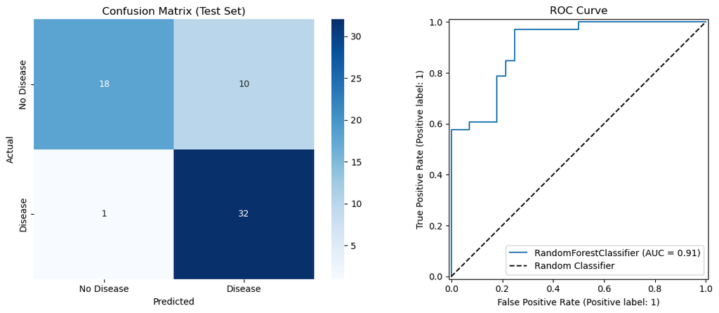

```python
fig, ax_pair = plt.subplots(1, 2, figsize=(12, 5))

# Confusion matrix
conf_mat = confusion_matrix(y_te, y_hat)
sns.heatmap(conf_mat, annot=True, fmt='d', cmap='Blues', ax=ax_pair[0],
            xticklabels=['No Disease', 'Disease'],
            yticklabels=['No Disease', 'Disease'])
ax_pair[0].set_title('Confusion Matrix (Test Set)')
ax_pair[0].set_xlabel('Predicted')
ax_pair[0].set_ylabel('Actual')

# ROC curve
RocCurveDisplay.from_estimator(tuned_model, X_te_scaled, y_te, ax=ax_pair[1])
ax_pair[1].plot([0, 1], [0, 1], 'k--', label='Random Classifier')
ax_pair[1].set_title('ROC Curve')
ax_pair[1].legend()

plt.tight_layout()
plt.show()
```

## 8. Feature Importance and Explainability

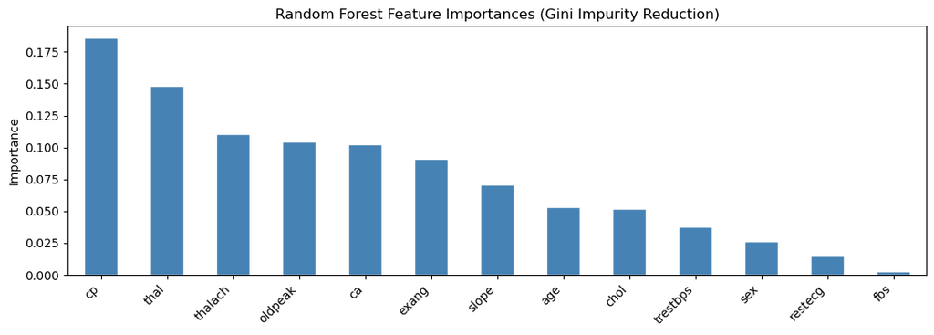

```
cp          0.1860
thal        0.1483
thalach     0.1106
oldpeak     0.1048
ca          0.1022
exang       0.0907
slope       0.0706
age         0.0530
chol        0.0521
trestbps    0.0379
sex         0.0264
restecg     0.0146
fbs         0.0027
```

```python
feat_scores = pd.Series(
    tuned_model.feature_importances_, index=features.columns
).sort_values(ascending=False)

feat_scores.plot.bar(figsize=(11, 4), color='steelblue', edgecolor='white',
                  title='Random Forest Feature Importances (Gini Impurity Reduction)')
plt.ylabel('Importance')
plt.xticks(rotation=45, ha='right')
plt.tight_layout()
plt.show()

print(feat_scores.round(4).to_string())
```

## 9. Critical Evaluation

**Limitations:** The dataset is pretty small (just 303 patients), so the findings don’t carry as much statistical weight and probably won’t generalize well outside the Cleveland sample. All the data comes from a single source, which brings in a bias that doesn’t cover more varied patient groups. Also, impurity-based feature importances can favor features with lots of possible values, so that might skew interpretation. And by making the task just binary, we ignore the spectrum of how severe someone’s disease actually is.

**Ethical Considerations:** False negatives classifying a patient as disease-free when disease is present, delay treatment and may cause serious harm. Model outputs must therefore serve as decision support rather than autonomous diagnosis, with mandatory clinician review before any clinical action. Healthcare ML deployments require human oversight, transparent reasoning, and ongoing performance auditing to ensure patient safety and regulatory compliance.

**Future Work:** Results would be stronger if we trained on a bigger and more diverse dataset that spans multiple centers and patient backgrounds. We need to validate the model on an entirely new group of patients before thinking about deployment. Tools like SHAP could help make the model’s decisions clearer for each individual patient. Adding more clinical information, like genetic data or measurements over time, might help the predictions get even better.

## 10. Business Recommendations and Conclusion

The tuned Random Forest model delivers solid predictions, picking up on the same key risk factors that clinicians already watch for in cardiovascular cases. That lines up well with what you'd expect in real medical practice.

**Recommendations:**

1. **Deploy as a clinical decision-support tool**, not a diagnostic replacement — model outputs should inform, not override, clinician judgement to maintain patient safety and physician accountability.
2. **Validate prospectively in real clinical settings** Test the model in real clinics before rolling it out. Just because it worked on one group before doesn’t mean it’ll work everywhere or with every patient.
3. **Collect larger, multi-centre datasets** to address the demographic limitations of the Cleveland cohort and improve robustness across age, sex, and ethnicity.
4. **Maintain mandatory physician oversight** Always have a physician oversee any decision using the model. If the model isn’t confident or something looks strange, there should be a clear process for getting expert backup.

**Tools Used**

- Python 3.12
- Pandas
- NumPy
- Scikit-learn
- Matplotlib
- Seaborn
- Jupyter Notebook

**References:**

- Gibbons, R.J. et al. (2002). ACC/AHA guideline update for stable angina. *JACC*, 41(1), 159–168.
- Janosi, A. et al. (1988). *Heart Disease Dataset*. UCI Machine Learning Repository.
- Bergstra, J. & Bengio, Y. (2012). Random search for hyper-parameter optimization. *JMLR*, 13, 281–305.
- Rudin, C. (2019). Stop explaining black box ML models for high stakes decisions. *Nature Machine Intelligence*, 1, 206–215.
- WHO (2021). *Cardiovascular Diseases Fact Sheet*. World Health Organization.